# PML Project - Predicting How Well People Exercise

Raphael Parrado

May 18, 2019

# Background

Using devices such as Jawbone Up, Nike FuelBand, and Fitbit it is now possible to collect a large amount of data about personal activity relatively inexpensively. These type of devices are part of the quantified self movement - a group of enthusiasts who take measurements about themselves regularly to improve their health, to find patterns in their behavior, or because they are tech geeks. One thing that people regularly do is quantify how much of a particular activity they do, but they rarely quantify how well they do it. In this project, your goal will be to use data from accelerometers on the belt, forearm, arm, and dumbell of 6 participants. They were asked to perform barbell lifts correctly and incorrectly in 5 different ways. More information is available from the website here: http://web.archive.org/web/20161224072740/http:/groupware.les.inf.puc-rio.br/har (see the section on the Weight Lifting Exercise Dataset).

## Data

The training data for this project are available here:

https://d396qusza40orc.cloudfront.net/predmachlearn/pml-training.csv

The test data are available here:

https://d396qusza40orc.cloudfront.net/predmachlearn/pml-testing.csv

# Preliminary Considerations

## Reproducibility

We used a seed generator, in this case 4321. Packages used were accessed and last versions are from 05/18/2019.

## Building the model

The outcome variable classe have 5 classes according to the activities performed: - exactly according to the specification (Class A) - throwing the elbows to the front (Class B) - lifting the dumbbell only halfway (Class C) - lowering the dumbbell only halfway (Class D) - throwing the hips to the front (Class E) Our variable A is an adequate use, the other variables are common mistakes. We used multiple models, but the two best models are exposed.

## Other Considerations

# Results

## Preliminary Data Loading

All packages have been previously loaded including: ggplot2, caret, rplot, randomforest, lattice, rpart and readr.

## Loading Data sets and cleaning

```r
## Loading Data sets
pml.training <- read_csv("pml-training.csv")
pml.testing <- read_csv("pml-testing.csv")

## Changing the classe column to factor
pml.training$classe <- as.factor(pml.training$classe)

## Deleting columns with no variables
pml.training<-pml.training[,colSums(is.na(pml.training)) == 0]
pml.testing <-pml.testing[,colSums(is.na(pml.testing)) == 0]

## Deleting columns that are not needed
pml.training <-pml.training[,-c(1:7)]
pml.testing <-pml.testing[,-c(1:7)]

## So what do we have
dim(pml.testing)
```

```
## [1] 20 53
```

```r
dim(pml.training)
```

```
## [1] 19622    53
```

```r
names(pml.training)
```

```
##  [1] "roll_belt"            "pitch_belt"           "yaw_belt"
##  [4] "total_accel_belt"     "gyros_belt_x"         "gyros_belt_y"
##  [7] "gyros_belt_z"         "accel_belt_x"         "accel_belt_y"
## [10] "accel_belt_z"         "magnet_belt_x"        "magnet_belt_y"
## [13] "magnet_belt_z"        "roll_arm"             "pitch_arm"
## [16] "yaw_arm"              "total_accel_arm"      "gyros_arm_x"
## [19] "gyros_arm_y"          "gyros_arm_z"          "accel_arm_x"
## [22] "accel_arm_y"          "accel_arm_z"          "magnet_arm_x"
## [25] "magnet_arm_y"         "magnet_arm_z"         "roll_dumbbell"
## [28] "pitch_dumbbell"       "yaw_dumbbell"         "total_accel_dumbbell"
## [31] "gyros_dumbbell_x"     "gyros_dumbbell_y"     "gyros_dumbbell_z"
## [34] "accel_dumbbell_x"     "accel_dumbbell_y"     "accel_dumbbell_z"
## [37] "magnet_dumbbell_x"    "magnet_dumbbell_y"    "magnet_dumbbell_z"
## [40] "roll_forearm"         "pitch_forearm"        "yaw_forearm"
## [43] "total_accel_forearm"  "gyros_forearm_x"      "gyros_forearm_y"
## [46] "gyros_forearm_z"      "accel_forearm_x"      "accel_forearm_y"
## [49] "accel_forearm_z"      "magnet_forearm_x"     "magnet_forearm_y"
## [52] "magnet_forearm_z"     "classe"
```

## Developing partitions for the model

```r
intrain <- createDataPartition(y=pml.training$classe, p=3/4, list=FALSE)
training <- pml.training[intrain,]
testing <- pml.training[-intrain,]
dim(training)
```

```
## [1] 14718    53
```

```r
dim(testing)
```

```
## [1] 4904   53
```

## So what do we have?

So as previusly discussed we have the variable classe with 5 levels. Let’s look the frequeny distribution of it.

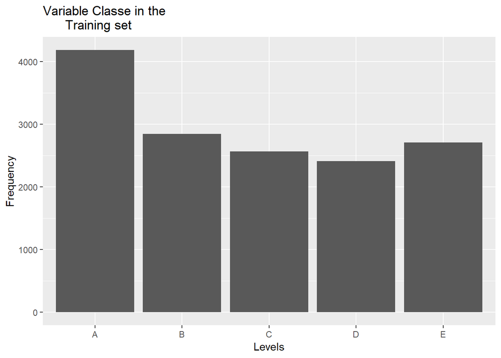

```r
##What data do we have
qplot(x=training$classe,main = "Variable Classe in the
      Training set", data=training,geom="bar",xlab="Levels",ylab="Frequency")
```

## Our first model - A Decision tree

```r
modfit1 <- rpart(classe~.,data=training,method="class")
prediction1<- predict(modfit1,testing,type="class")
confusionMatrix(prediction1,testing$classe)
```

```
## Confusion Matrix and Statistics
##
##           Reference
## Prediction    A    B    C    D    E
##          A 1245  195   19   73   27
##          B   29  487   81   24   46
##          C   42   96  680  129  106
##          D   51   80   51  525   51
##          E   28   91   24   53  671
##
## Overall Statistics
##
##                Accuracy : 0.7357
##                  95% CI : (0.7231, 0.748)
##     No Information Rate : 0.2845
##     P-Value [Acc > NIR] : < 2.2e-16
##
##                   Kappa : 0.6646
##
##  Mcnemar's Test P-Value : < 2.2e-16
##
## Statistics by Class:
##
##                      Class: A Class: B Class: C Class: D Class: E
## Sensitivity            0.8925  0.51317   0.7953   0.6530   0.7447
## Specificity            0.9105  0.95449   0.9079   0.9432   0.9510
## Pos Pred Value         0.7986  0.73013   0.6458   0.6926   0.7739
## Neg Pred Value         0.9552  0.89096   0.9546   0.9327   0.9430
## Prevalence             0.2845  0.19352   0.1743   0.1639   0.1837
## Detection Rate         0.2539  0.09931   0.1387   0.1071   0.1368
## Detection Prevalence   0.3179  0.13601   0.2147   0.1546   0.1768
## Balanced Accuracy      0.9015  0.73383   0.8516   0.7981   0.8479
```

So we have an accuracy of around 75%.

## Second model - A random forest

```r
modfit2 <- train(classe~.,data=training, method="rf",ntree=20)
prediction2 <- predict(modfit2,testing)
confusionMatrix(prediction2,testing$classe)
```

```
## Confusion Matrix and Statistics
##
##           Reference
## Prediction    A    B    C    D    E
##          A 1393   11    0    0    0
##          B    2  931   13    0    0
##          C    0    6  836   12    0
##          D    0    1    6  791    2
##          E    0    0    0    1  899
##
## Overall Statistics
##
##                Accuracy : 0.989
##                  95% CI : (0.9857, 0.9917)
##     No Information Rate : 0.2845
##     P-Value [Acc > NIR] : < 2.2e-16
##
##                   Kappa : 0.9861
##
##  Mcnemar's Test P-Value : NA
##
## Statistics by Class:
##
##                      Class: A Class: B Class: C Class: D Class: E
## Sensitivity            0.9986   0.9810   0.9778   0.9838   0.9978
## Specificity            0.9969   0.9962   0.9956   0.9978   0.9998
## Pos Pred Value         0.9922   0.9841   0.9789   0.9888   0.9989
## Neg Pred Value         0.9994   0.9955   0.9953   0.9968   0.9995
## Prevalence             0.2845   0.1935   0.1743   0.1639   0.1837
## Detection Rate         0.2841   0.1898   0.1705   0.1613   0.1833
## Detection Prevalence   0.2863   0.1929   0.1741   0.1631   0.1835
## Balanced Accuracy      0.9977   0.9886   0.9867   0.9908   0.9988
```

Here the accuracy is about 99%.

## Final thoughts and decision for modeling

After evaluating both models is evident that the Random Forest is the best model with a vast difference in accuracy. The speific accuracy is 0.989 ith an out of sample error of 0.011 which is more than ideal.

Based on this we then apply the model to our testing data that includes 20 cases.

```r
finalpredict <- predict(modfit2,pml.testing)
finalpredict
```

```
##  [1] B A B A A E D B A A B C B A E E A B B B
## Levels: A B C D E
```

# References

[1] Velloso, E.; Bulling, A.; Gellersen, H.; Ugulino, W.; Fuks, H. Qualitative Activity Recognition of Weight Lifting Exercises. Proceedings of 4th International Conference in Cooperation with SIGCHI (Augmented Human ’13) . Stuttgart, Germany: ACM SIGCHI, 2013. [2] Krzysztof Gra??bczewski and Norbert Jankowski. Feature Selection with Decision Tree Criterion.